# Exercise 2 - Downloading Fire Weather Data

# Objectives

TODO:

- Plot using basic plots with ggplot2
- Download data from riem (install packages)

## Turning on the libraries we will need:

Let’s turn on `ggplot2`

```r
library("ggplot2")
library("lubridate")
skunkData_reloaded <- read.csv("skunkData_dateAdded.csv")
skunkData_reloaded$DateTime <- ymd_hms(skunkData_reloaded$DateTime,tz = "MST")
```

## Plotting Your Data

Now that we know a bit about plotting, let’s plot our own data.

Let’s plot RH over time using lines:

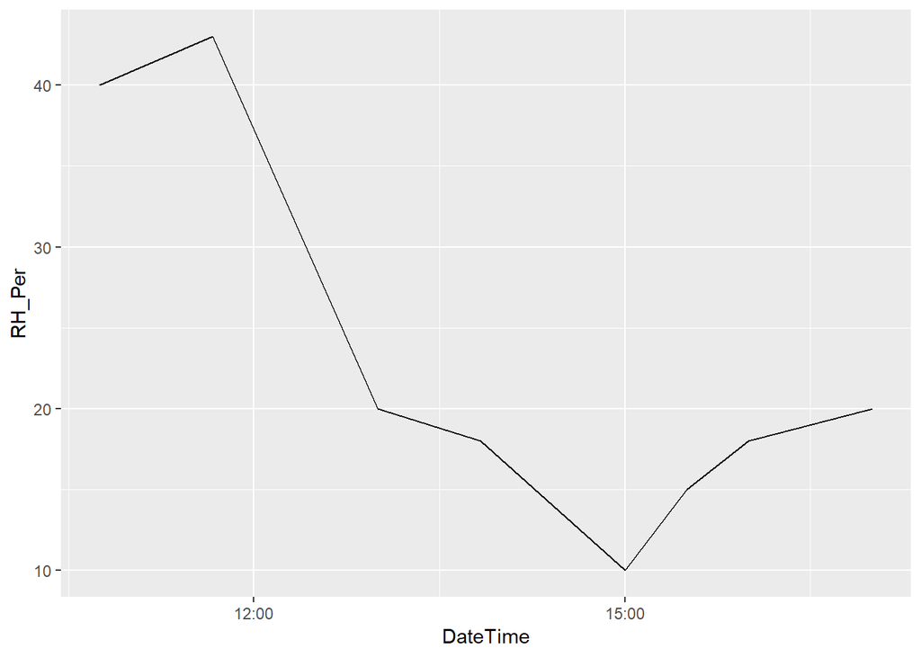

```r
p <- ggplot(data = skunkData_reloaded, aes(x = DateTime, y = RH_Per))+
  geom_line()

p
```

Let’s add points:

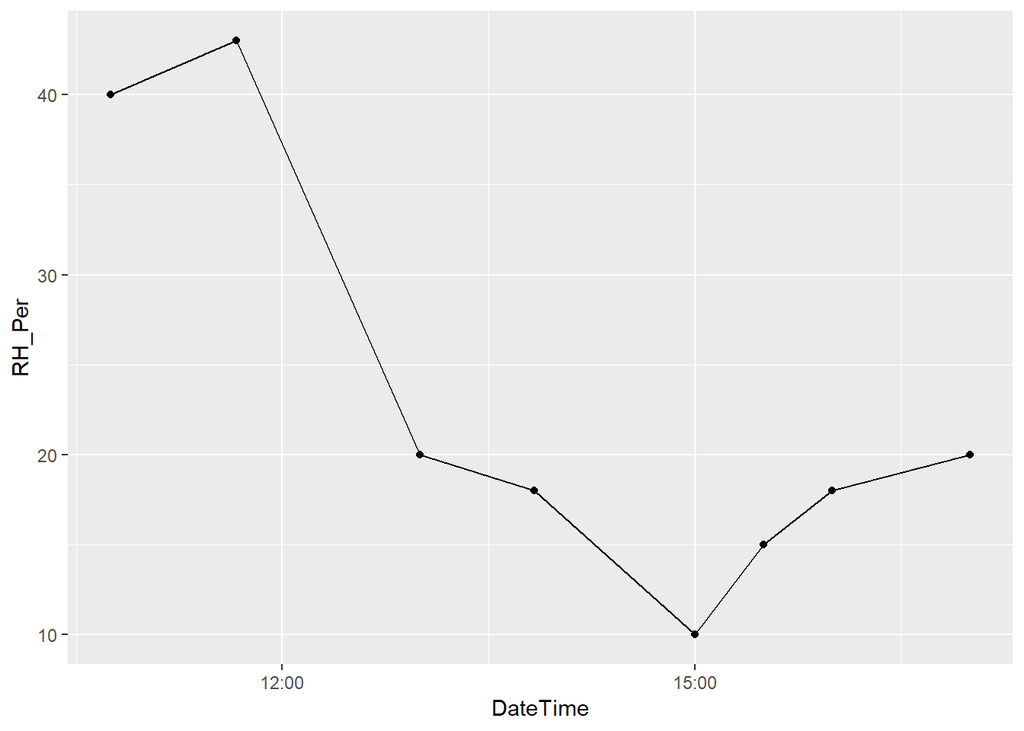

```r
p + geom_point()
```

We can also change the color of points

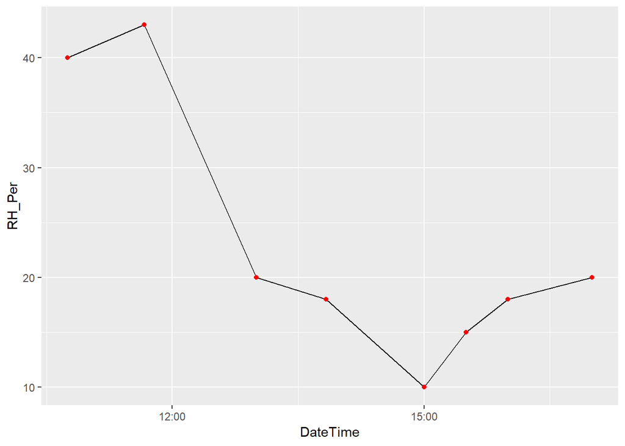

```r
p + geom_point(color = "red")
```

or the shape…

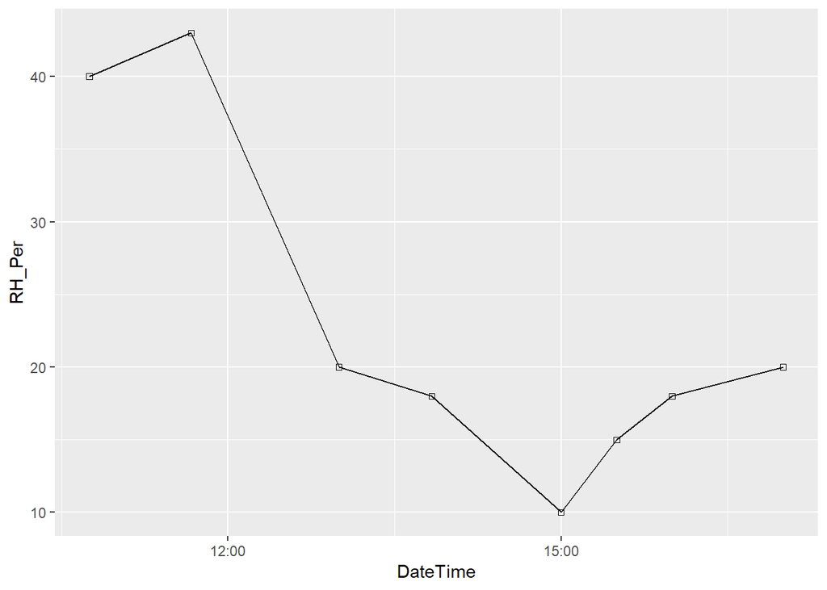

```r
p + geom_point(shape = 22)
```

We can also clean it up a little:

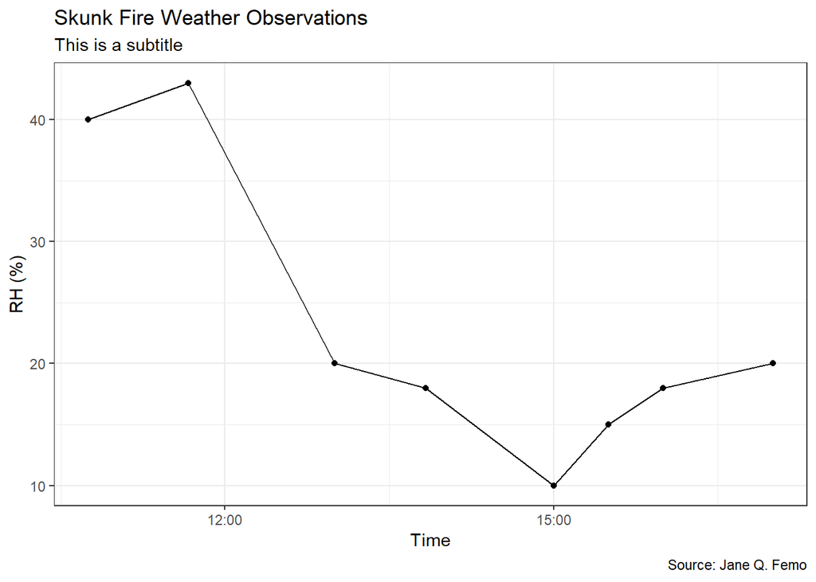

```r
p + geom_point()+
  xlab("Time")+
  ylab("RH (%)")+
  labs(title = "Skunk Fire Weather Observations",
       subtitle = "This is a subtitle",
       caption = "Source: Jane Q. Femo")+
  theme_bw()
```

### Challenge

- Plot temperature with ggplot2 against time
- Change the point color to green
- Change the point shape to a triangle (24)

## Downloading new data

### Installing riem

Let’s download some nearby weather observations and plot them alongside these data.

First, let’s download the `riem` R package, a wrapper for the Iowa Environmental Mesonet

```r
install.packages("riem")
library("riem")
```

Great! Hopefully no errors.

### Downloading data

We will use the `riem_measures` function, explained in documentation [here](http://ropensci.github.io/riem/reference/riem_measures.html).

The closest NWS station to the Skunk Fire is FNL, so let’s download the corresponding date:

```r
FCO <- riem_measures("FNL", date_start = "2018-09-22", date_end = "2018-09-24")
```

Great! Let’s take a look at how the data are structured and plot it:

```r
str(FCO)
```

```
## Classes 'tbl_df', 'tbl' and 'data.frame':    626 obs. of  31 variables:
##  $ station          : chr  "FNL" "FNL" "FNL" "FNL" ...
##  $ valid            : POSIXct, format: "2018-09-22 00:00:00" "2018-09-22 00:05:00" ...
##  $ lon              : num  -105 -105 -105 -105 -105 ...
##  $ lat              : num  40.5 40.5 40.5 40.5 40.5 ...
##  $ tmpf             : num  NA NA NA NA NA NA NA NA NA NA ...
##  $ dwpf             : num  NA NA NA NA NA NA NA NA NA NA ...
##  $ relh             : num  NA NA NA NA NA NA NA NA NA NA ...
##  $ drct             : num  120 120 110 110 110 110 110 110 110 110 ...
##  $ sknt             : num  6 8 8 12 10 9 10 10 10 9 ...
##  $ p01i             : num  NA NA NA NA NA NA NA NA NA NA ...
##  $ alti             : num  30.2 30.2 30.2 30.2 30.2 ...
##  $ mslp             : num  NA NA NA NA NA NA NA NA NA NA ...
##  $ vsby             : num  10 10 10 10 10 10 10 10 10 10 ...
##  $ gust             : num  NA NA NA NA NA NA NA NA NA NA ...
```

[output cut: 17 more lines]

```r
head(FCO)
```

```
## # A tibble: 6 x 31
##   station valid                 lon   lat  tmpf  dwpf  relh  drct  sknt
##   <chr>   <dttm>              <dbl> <dbl> <dbl> <dbl> <dbl> <dbl> <dbl>
## 1 FNL     2018-09-22 00:00:00 -105.  40.5    NA    NA    NA   120     6
## 2 FNL     2018-09-22 00:05:00 -105.  40.5    NA    NA    NA   120     8
## 3 FNL     2018-09-22 00:10:00 -105.  40.5    NA    NA    NA   110     8
## 4 FNL     2018-09-22 00:15:00 -105.  40.5    NA    NA    NA   110    12
## 5 FNL     2018-09-22 00:20:00 -105.  40.5    NA    NA    NA   110    10
## 6 FNL     2018-09-22 00:25:00 -105.  40.5    NA    NA    NA   110     9
## # ... with 22 more variables: p01i <dbl>, alti <dbl>, mslp <dbl>,
## #   vsby <dbl>, gust <dbl>, skyc1 <chr>, skyc2 <lgl>, skyc3 <lgl>,
## #   skyc4 <lgl>, skyl1 <lgl>, skyl2 <lgl>, skyl3 <lgl>, skyl4 <lgl>,
## #   wxcodes <chr>, ice_accretion_1hr <lgl>, ice_accretion_3hr <lgl>,
## #   ice_accretion_6hr <lgl>, peak_wind_gust <lgl>, peak_wind_drct <lgl>,
## #   peak_wind_time <lgl>, feel <dbl>, metar <chr>
```

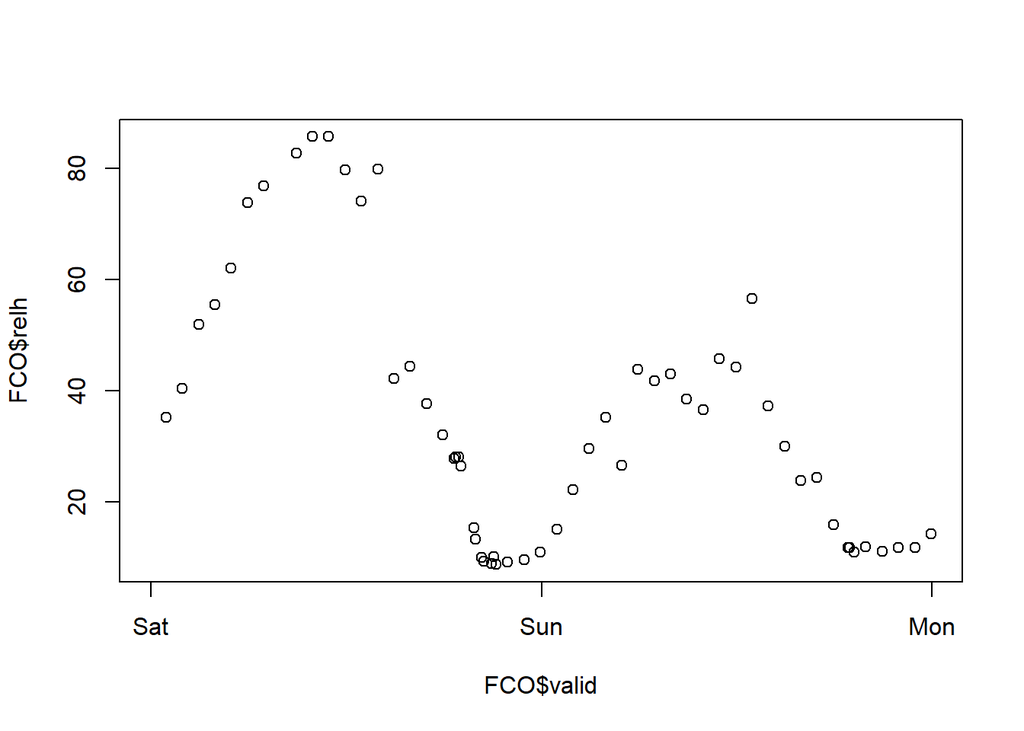

```r
plot(FCO$relh~FCO$valid)
```

Close readers may note that this is not a dataframe but a tibble.

Now let’s overlay it with our data. How can we do that?

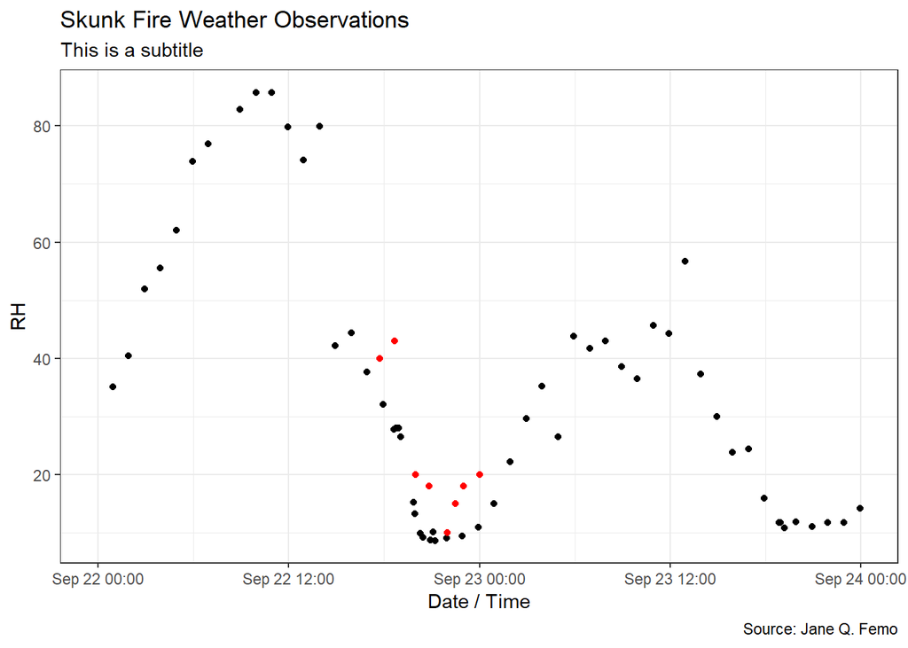

```r
p2 <- ggplot()+
  xlab("Date / Time")+
  ylab("RH")+
  geom_point(color = "black", data = FCO, aes(x = valid, y = relh))+
  geom_point(color = "red", data = skunkData_reloaded, aes(x = DateTime, y = RH_Per))+
  labs(title = "Skunk Fire Weather Observations",
       subtitle = "This is a subtitle",
       caption = "Source: Jane Q. Femo")+
  theme_bw()

p2
```

Uh oh, that looks weird. Maybe the time zones are off? Let’s check it! And FIX IT!

```r
tz(FCO$valid)
```

```
## [1] "UTC"
```

```r
FCO$DateTime <- with_tz(FCO$valid, "MST")
```

Let’s plot this again.

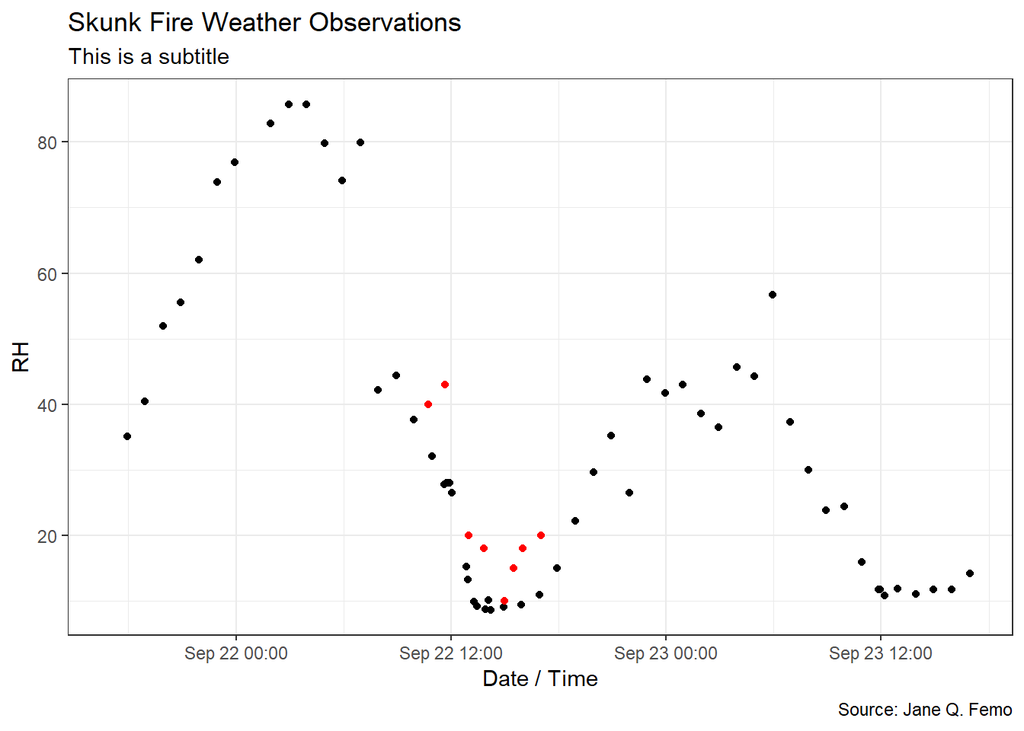

```r
p2 <- ggplot()+
  xlab("Date / Time")+
  ylab("RH")+
  geom_point(color = "black", data = FCO, aes(x = DateTime, y = relh))+
  geom_point(color = "red", data = skunkData_reloaded, aes(x = DateTime, y = RH_Per))+
  labs(title = "Skunk Fire Weather Observations",
       subtitle = "This is a subtitle",
       caption = "Source: Jane Q. Femo")+
  theme_bw()

p2
```

Cool!

How can we make this look nicer, though?

Let’s use the package `cowplot`

Go ahead and install it and switch the theme to `theme_cowplot()`

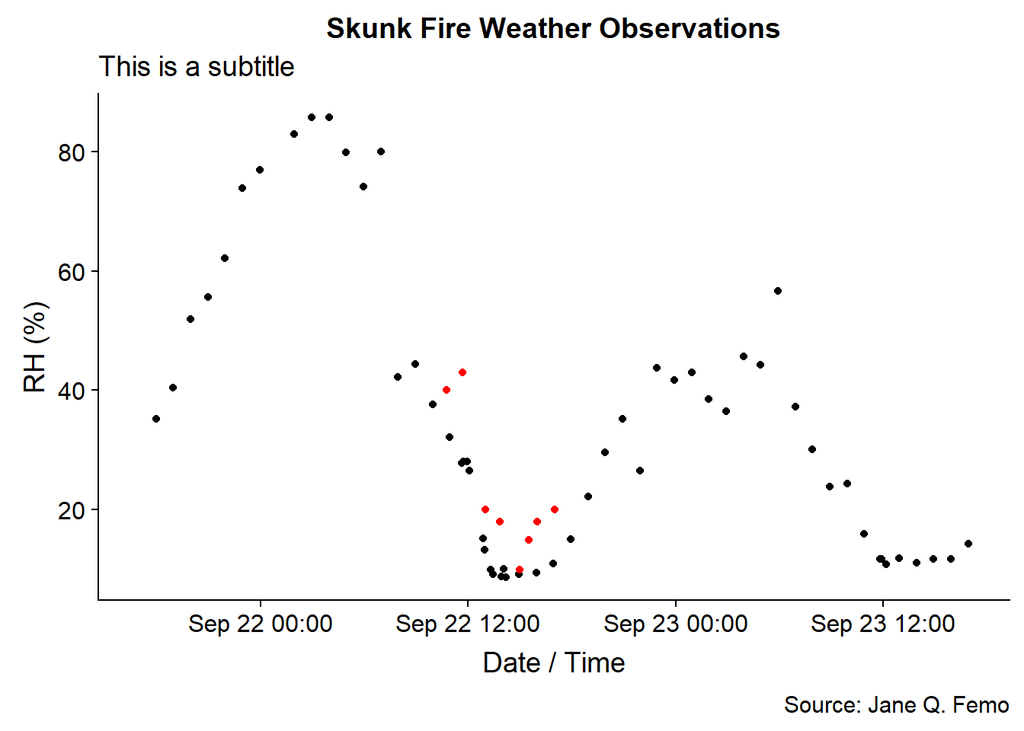

```r
library(cowplot)
p2 <- ggplot()+
  xlab("Date / Time")+
  ylab("RH (%)")+
  geom_point(color = "black", data = FCO, aes(x = DateTime, y = relh))+
  geom_point(color = "red", data = skunkData_reloaded, aes(x = DateTime, y = RH_Per))+
  labs(title = "Skunk Fire Weather Observations",
       subtitle = "This is a subtitle",
       caption = "Source: Jane Q. Femo")+
  theme_cowplot()

p2
```

Looking good! Let’s play with dates some more and fix the scale to just show one day. We will need to use the `scale_x_datetime` scale function, which takes values for limits.

This is a bit advanced but with some good googling for “POSIXct”, “ggplot2”, and “scale_x_datetime”, I bet you can find the answer…

Stack Overflow to the rescue!

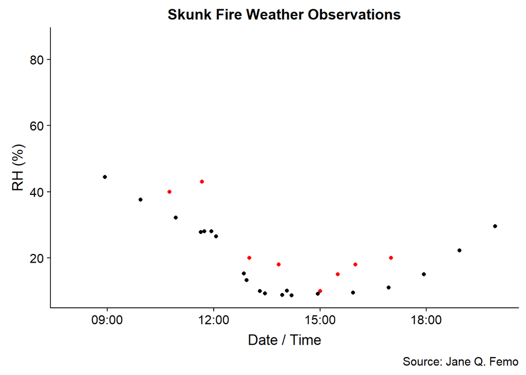

```r
p2 <- ggplot()+
  xlab("Date / Time")+
  ylab("RH (%)")+
  scale_x_datetime(limits = ymd_h(c("2018-09-22 08", "2018-09-22 20"),tz = "MST"))+
  geom_point(color = "black", data = FCO, aes(x = DateTime, y = relh))+
  geom_point(color = "red", data = skunkData_reloaded, aes(x = DateTime, y = RH_Per))+
  labs(title = "Skunk Fire Weather Observations",
       caption = "Source: Jane Q. Femo")+
  theme_cowplot()

p2
```

Now we’re cooking with gas. Let’s save this using the `ggsave` function.

```r
ggsave(plot = p2, filename = "SkunkFireRH.png")
```

### Challenge

- Plot the temperature from the Skunk Fire in green and the temperature (tmpf) of from the FCO airport data in red squares (shape 15)
- Change the title of the plot to “Skunk Fire Weather: On-Site and Regional Comparison”
- Save the plot as “SkunkFireTemperature.png”